# R Notebook

Load the csv file

```r
Vis =read.csv("assignment_dataVis_dataset.csv")
```

Split by conditions

```r
split_df <- split(Vis, Vis$condition)

condition_1 <- split_df$condition_1
condition_2 <- split_df$condition_2
condition_3 <- split_df$condition_3
condition_4 <- split_df$condition_4


library(ggplot2)
```

# Condition 1

```r
mean(condition_1$x)
```

```
## [1] 54.26327
```

```r
sd(condition_1$x)
```

```
## [1] 16.76514
```

```r
mean(condition_1$y)
```

```
## [1] 47.83225
```

```r
sd(condition_1$y)
```

```
## [1] 26.9354
```

Visualization

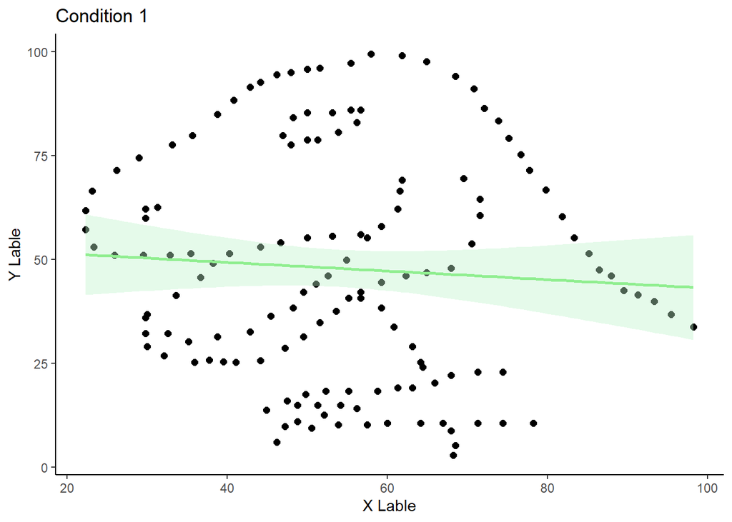

```r
ggplot(data = condition_1, aes(x, y)) +
  geom_point(color = "black", size = 2) +
  geom_smooth(method = "lm", color = "lightgreen", fill = "#bef3cb", se = TRUE) +
  labs(title = "Condition 1",
       x = "X Lable",
       y = "Y Lable") +
  theme_classic()
```

# Condition 2

```r
mean(condition_2$x)
```

```
## [1] 54.26873
```

```r
sd(condition_2$x)
```

```
## [1] 16.76924
```

```r
mean(condition_2$y)
```

```
## [1] 47.83082
```

```r
sd(condition_2$y)
```

```
## [1] 26.93573
```

Visualization

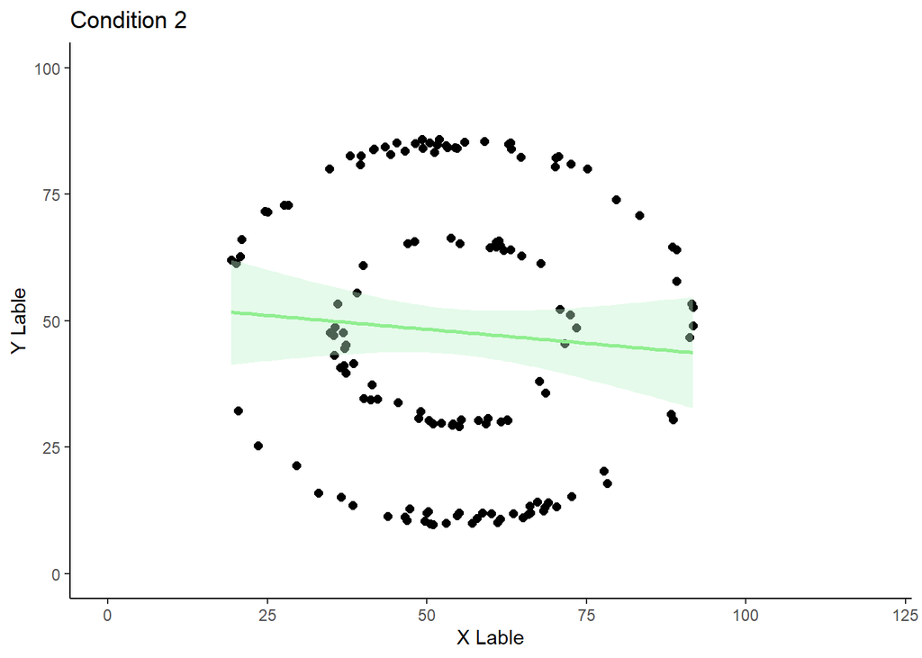

```r
ggplot(data = condition_2, aes(x, y)) +
  geom_point(color = "black", size = 2) +
  geom_smooth(method = "lm", color = "lightgreen", fill = "#bef3cb", se = TRUE) +
  labs(title = "Condition 2",
       x = "X Lable",
       y = "Y Lable") +
  xlim(0,120) +
  ylim(0,100) +
  theme_classic()
```

# Condition 3

```r
mean(condition_3$x)
```

```
## [1] 54.26588
```

```r
sd(condition_3$x)
```

```
## [1] 16.76885
```

```r
mean(condition_3$y)
```

```
## [1] 47.8315
```

```r
sd(condition_3$y)
```

```
## [1] 26.93861
```

visualization

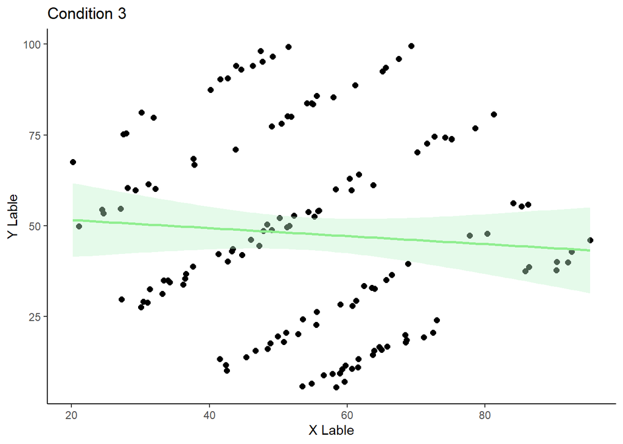

```r
ggplot(data = condition_3, aes(x, y)) +
  geom_point(color = "black", size = 2) +
  geom_smooth(method = "lm", color = "lightgreen", fill = "#bef3cb", se = TRUE) +
  labs(title = "Condition 3",
       x = "X Lable",
       y = "Y Lable") +
  theme_classic()
```

# Condition 4

```r
mean(condition_4$x)
```

```
## [1] 54.26734
```

```r
sd(condition_4$x)
```

```
## [1] 16.76896
```

```r
mean(condition_4$y)
```

```
## [1] 47.83955
```

```r
sd(condition_4$y)
```

```
## [1] 26.93027
```

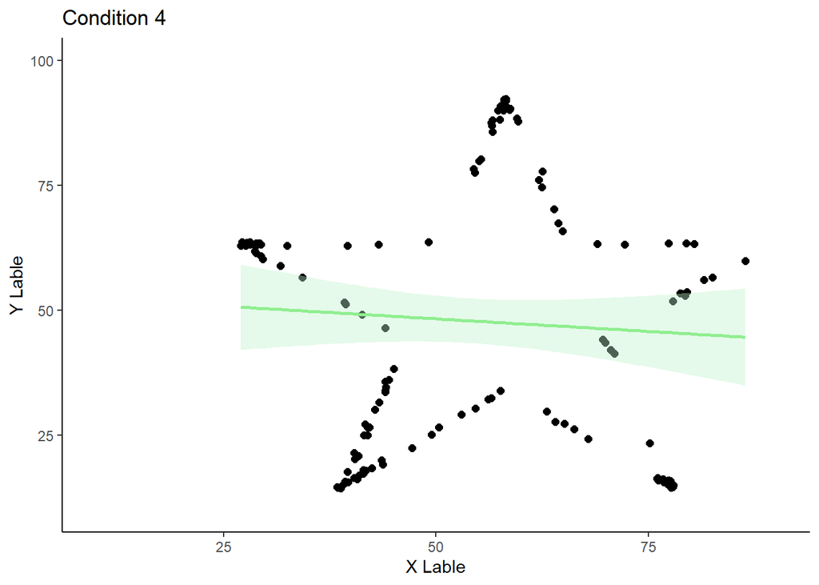

```r
ggplot(data = condition_4, aes(x, y)) +
  geom_point(color = "black", size = 2) +
  geom_smooth(method = "lm", color = "lightgreen", fill = "#bef3cb", se = TRUE) +
  labs(title = "Condition 4",
       x = "X Lable",
       y = "Y Lable") +
  xlim(10,90) +
  ylim(10,100) +
  theme_classic()
```

Questions on Step 5

What can be concluded from the dataset?

- Although the summary of the data are similar (e.g. mean and standard deviation), they are quite different when visualize. The data points are located differently which show diverse figures here.

What did you find most challenging about this assignment?

- The data frame is hard to be separated. The “wide” code was not working well so I discussed with my classmates and set 4 individual data sets for each.

What did you learn in completing this assignment? What are you still curious about?

- I tried many graphs to visualize the data set and found the scatter plot show everything the best. I really like the process that the table became clear and beautiful.
- Online websites are very useful when trying to learn something new and create a complicated code set.
- I also wonder if R can recognize the shape and create a better trend line based on the graph.

Why is it important to visualize data?

- As we found in this data set. The summary of each conditions are actually very similar. If we don’t visualize them, it’s hard or even impossible to find the difference especially with larger amount of information.
- It’s good for communicating with the public with the graphs since they reduce the difficulty of understanding and improve communication efficiency.
- Save time and energy for the researchers when doing studies.